# Computing Agroclimate Metrics in R

Part I. Intro and Simple Metrics

[figure not shown]

December 2, 2022  
https://ucanr-igis.github.io/agroclimR/

[figure not shown]

# Start Recording

[figure not shown]

# About Me…

[figure not shown]

# IGIS Team

[figure not shown]

# Open-Source Resources for Decision Support Tools

[figure not shown]

# About You

Type of Organization

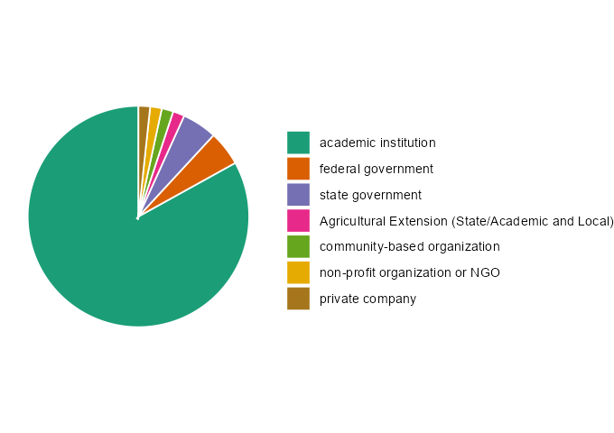

Email domain

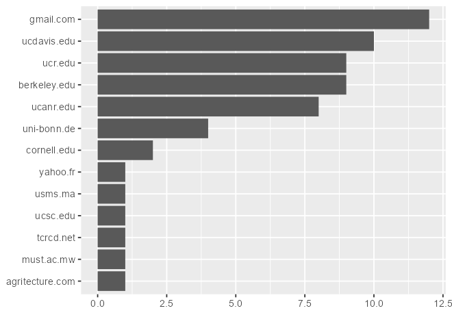

Location

[interactive chart not shown]

Familiarity with Agroclimate Metrics

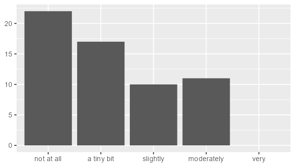

Familiarity with R

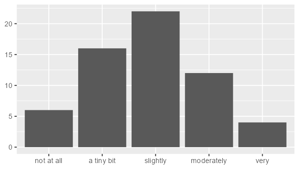

# Today’s Outline

## Part I. Intro and Computationally Simple Metrics

- Intro to Agroclimate Metrics
- Weather data
- R tricks
  - data wrangling
  - ggplot 101
  - working with dates
- Notebook #1: Simple Metrics with CIMIS Data

## Part II. Cumulative Metrics and Multi-year Summaries

- Degree days
- Chill portions
- R tricks
  - Multi-year summaries
  - Grouping rows
- Notebook #2

## Part III. Agroclimate Metrics with Modeled Climate Data

- Climate data: LOCA downscaled CIMP5 climate projections
- Best Practices with modeled climate data
- Climate metrics to business metrics
- Stacking and chaining metrics
- Bioclimatic analogues
- Bioclimatic rasters

# Workshop Goals

Develop general familiarity with:

- agroclimate metrics
- weather data
- data wrangling methods in R
- specialized R packages

Come away with:

- some hands-on experience
- working code recipes!

Workshop materials:

- Slides: https://ucanr-igis.github.io/agroclimR/
- RStudio project: https://posit.cloud/content/5055980
- GitHub repo: https://github.com/ucanr-igis/agroclimR

# Agroclimate Metrics

Agroclimate metrics reflect *weather driven factors* that *influence the development* of plants and insects.

Examples:

- extreme heat days
- tropical nights
- heatwaves
- accumulated degree days
- frost days
- winter chill
- dates of first fall freeze & last spring freeze
- diurnal temperature range
- evapotranspiration

These are *abiotic* factors but they influence biotic factors that affect crops (like disease).

The main ingredients of metrics are *measurements* of *weather variables* (like air temperature).

We can compute them for the *past*, *present*, and *future*.

# Why are they useful?

## Weather derived metrics are generally good predictors of growth

[figure not shown]

Pistachio nut embryo length vs degree days  
Zhang et al ([2021](https://doi.org/10.21273/HORTSCI15722-21))

## Managing Farm Operations

### Optimize Pest Management

- Timing is everything in integrated pest management
- Save $$ and reduce harmful side effects

[figure not shown]

### Scheduling

- Irrigation scheduling and amounts
- When to start deficit irrigation
- Put out traps
- Schedule harvest crews
- Plan for the coming season

[figure not shown]

## Understanding the Effects of Climate Change

| https://doi.org/10.1016/j.ufug.2018.07.020 | Where can I go today to see the climate my city will have 50 years from now? |
| --- | --- |
| How many generations of Navel Orangeworm will growers have to deal with in the coming decades? | https://doi.org/10.1016/j.scitotenv.2020.142657 |
| https://doi.org/doi:10.1371/journal.pone.0020155 | How much chill can we expect in the coming decades? Will there be enough to have a economically viable farming operation? |
| What kind of frost exposure will we see mid-century? | https://doi.org/10.1016/j.scitotenv.2020.143971 |
| https://doi.org/10.3390/agronomy12010205 | What is the ‘new normal’ for agroclimatic metrics for specialty crops? |

# Why would you want to do these in R?

R is an *extremely* flexible computing environment,  
with strengths in:

- data manipulation
- visualization
- data modeling
- integrating other data
- widely taught
- strong user community

[figure not shown]

Access weather and climate data

[figure not shown]

owmr: OpenWeatherMap API Wrapper  
rnoaa: ‘NOAA’ Weather Data from R  
riem: Accesses Weather Data from the Iowa Environment Mesonet  
…plus many others  
Or write your own!

[figure not shown]

# Weather Data

## Station Based

- Highest quality data are from sensors  
  mounted on weather stations
- Many public and private networks
- Many are online
- Closer is better
- On-site is best
- Near ground is good

[figure not shown]

Typical variables:

- air temperature
- solar radiation
- relative humidity
- dew point
- precipitation
- soil temperature
- soil moisture
- vapor pressure
- wind speed
- wind direction

## Interpolated / Gridded Data

- based on weather station data with modeling
- [PRISM](https://prism.oregonstate.edu/) (continental USA, 1979 - present, 800m & 4km)
- [gridMET](https://www.climatologylab.org/gridmet.html) (continental USA, based on PRISM)
- [Livneh](https://psl.noaa.gov/data/gridded/data.livneh.html) (continental USA, 1950–2013, 6km)

[figure not shown]

## Accessing Data

File server

- files may cover a large area
- files may be big
- you have to read the file and  
  extract the AOI yourself

[figure not shown]

API service

- communication between computers
- just get what you need
- may require registration
- may require a subscription fee

[figure not shown]

# R-tricks: Piping

**Piping syntax** is an alternative way of chaining functions together than nested parentheses:

zoo(moo(boo(foo(99),k=7),n=4))

With piping, you use the pipe operator |> or %>% to ‘feed’ the result of one function as the **first argument** to the next function.

[figure not shown]

- Keyboard shortcut for inserting the pipe operator: `ctrl + shift + m`  
  You can tell RStudio which pipe to insert under Tools >> Global Options >> Code  
  `|>` (‘native’ pipe introduced R4.0)  
  `%>%` (traditional, requires magrittr package)

# R-tricks: Data wrangling

Whatever is needed to get your data frame ready for the function(s)  
you need for analysis and visualization.

[figure not shown]

- dropping columns
- renaming columns
- changing the order of columns
- creating new columns with an expression
- filtering rows
- sorting rows
- going from ‘long’ to ‘wide’ formats
- joining data frames based on a common field
- stacking / appending data frames
- splitting tables
- aggregating rows into groups

The go-to package for wrangling data frames is [`dplyr`](https://dplyr.tidyverse.org):

[figure not shown]

## Common `dplyr` Functions

| subset rows | filter(), slice() |
| --- | --- |
| order rows | arrange(), arrange(desc()) |
| pick column(s) | select(), pull() |
| add new columns | mutate() |
| offset rows | lead(), lag() |
| vectorized conditional checks | if_else(), case_when() |
| join data frames | left_join(), right_join(), inner_join() |

# Chaining dplyr functions

Most `dplyr` functions *take a tibble*, and *return a tibble*.

This makes them very *pipe friendly*.

## Example

```r
library(dplyr)
head(storms)
```

```
## # A tibble: 6 × 13
##   name   year month   day  hour   lat  long status categ…¹  wind press…² tropi…³
##   <chr> <dbl> <dbl> <int> <dbl> <dbl> <dbl> <chr>  <ord>   <int>   <int>   <int>
## 1 Amy    1975     6    27     0  27.5 -79   tropi… -1         25    1013      NA
## 2 Amy    1975     6    27     6  28.5 -79   tropi… -1         25    1013      NA
## 3 Amy    1975     6    27    12  29.5 -79   tropi… -1         25    1013      NA
## 4 Amy    1975     6    27    18  30.5 -79   tropi… -1         25    1013      NA
## 5 Amy    1975     6    28     0  31.5 -78.8 tropi… -1         25    1012      NA
## 6 Amy    1975     6    28     6  32.4 -78.7 tropi… -1         25    1012      NA
## # … with 1 more variable: hurricane_force_diameter <int>, and abbreviated
## #   variable names ¹category, ²pressure, ³tropicalstorm_force_diameter
```

*Which category 3 hurricane had the largest diameter of hurricane force winds?*

We can answer this question in one easy-to-read expression:

```r
storms %>%
  select(name, year, month, day, hour, category, status, hurricane_force_diameter) |>  ## select the columns we need
  filter(category == 3) |>                                                             ## category 3
  arrange(desc(hurricane_force_diameter)) |>                                           ## arrange descending by diameter
  slice(1:3)                                                                           ## show the top 3
```

```
## # A tibble: 3 × 8
##   name    year month   day  hour category status    hurricane_force_diameter
##   <chr>  <dbl> <dbl> <int> <dbl> <ord>    <chr>                        <int>
## 1 Ivan    2004     9    16     0 3        hurricane                      165
## 2 Ivan    2004     9    16     6 3        hurricane                      165
## 3 Nicole  2016    10    13    15 3        hurricane                      160
```

Note also that with dplyr functions you generally don’t have to put column names in quotes.

# R-tricks: Reshaping Data

*Reshaping* data includes:

- turning rows into columns (aka pivot tables, cross tab query)
- turning columns into rows

The go-to tidyverse package for reshaping data frames is [`tidyr`](https://tidyr.tidyverse.org):

[figure not shown]

## Common `tidyr` Functions

pivot_wider()

[figure not shown]

pivot_longer()

[figure not shown]

# R-tricks: Dates

Agroclimate metrics frequently requires working with **date values**.

These are **not** Date objects:

```r
x <- "2021-06-15"

y <- "4/1/2019"
```

To convert date-formatted text to Date objects use `as.Date()`:

```r
bloom_date <- as.Date("2021-04-15")
class(bloom_date)
```

```
## [1] "Date"
```

For everything else…

[figure not shown]

# Finding heat spells with `rle()`

Heat spells or heat waves are often defined as number of consecutive days where the maximum temperature exceeds a certain threshold.

It is relatively easy to flag which days exceed a threshold:

```r
grwsn_hotyn <- grwsn_dailymax_tbl |>
  mutate(hotyn = (max_temp > 100))
```

We can pull out consecutive days of high temperatures with the `rle()` function.

## `rle()`

Run length encoding is a way to compress data that is i) ordered, and ii) has repetitions. The best way to see how it works is with an illustration:

[figure not shown]

Now imagine we have time series data where TRUE means a hot day:

[figure not shown]

To compute this with `rle()`:

```r
hotdays_df <- data.frame(dt = seq(from = as.Date("2020-06-01"), to = as.Date("2020-06-19"), by = 1),
                      hotyn = c(T,T,F,F,F,F,F,T,T,T,T,T,F,F,F,F,T,T,T))
hotdays_df
```

```
##            dt hotyn
## 1  2020-06-01  TRUE
## 2  2020-06-02  TRUE
## 3  2020-06-03 FALSE
## 4  2020-06-04 FALSE
## 5  2020-06-05 FALSE
## 6  2020-06-06 FALSE
## 7  2020-06-07 FALSE
## 8  2020-06-08  TRUE
## 9  2020-06-09  TRUE
## 10 2020-06-10  TRUE
## 11 2020-06-11  TRUE
## 12 2020-06-12  TRUE
## 13 2020-06-13 FALSE
## 14 2020-06-14 FALSE
## 15 2020-06-15 FALSE
## 16 2020-06-16 FALSE
## 17 2020-06-17  TRUE
## 18 2020-06-18  TRUE
## 19 2020-06-19  TRUE
```

First, run the vector in rle():

```r
x <- rle(hotdays_df$hotyn)
x$values
```

```
## [1]  TRUE FALSE  TRUE FALSE  TRUE
```

```r
x$lengths
```

```
## [1] 2 5 5 4 3
```

Now we can write R expressions to pull out what we want.

```r
## Which groups meet both conditions to be a heat wave?
group_is_heatwave <- (x$values == TRUE) & (x$lengths >= 3)
group_is_heatwave
```

```
## [1] FALSE FALSE  TRUE FALSE  TRUE
```

```r
## Number of heatwaves in this period
sum(group_is_heatwave)
```

```
## [1] 2
```

# ggplot 101

```r
library(palmerpenguins)
head(penguins)
```

```
## # A tibble: 6 × 8
##   species island    bill_length_mm bill_depth_mm flipper_l…¹ body_…² sex    year
##   <fct>   <fct>              <dbl>         <dbl>       <int>   <int> <fct> <int>
## 1 Adelie  Torgersen           39.1          18.7         181    3750 male   2007
## 2 Adelie  Torgersen           39.5          17.4         186    3800 fema…  2007
## 3 Adelie  Torgersen           40.3          18           195    3250 fema…  2007
## 4 Adelie  Torgersen           NA            NA            NA      NA <NA>   2007
## 5 Adelie  Torgersen           36.7          19.3         193    3450 fema…  2007
## 6 Adelie  Torgersen           39.3          20.6         190    3650 male   2007
## # … with abbreviated variable names ¹flipper_length_mm, ²body_mass_g
```

Make a scatter plot:

```r
ggplot(penguins, aes(x = flipper_length_mm, y = bill_length_mm, color = species)) +
  geom_point() +
  ggtitle("Bill Length vs Flipper Length for 3 Species of Penguins")
```

[figure not shown]

# Anatomy of a ggplot

[figure not shown]

# R Notebooks

R Notebooks are written in “R Markdown”, which combines text and R code.

[figure not shown]

# Notebook 1: Simple Metrics with CIMIS Data

1. Import CIMIS weather station data
2. Time slice by dates
3. Compute rolling averages
4. Threshold based metrics
5. Spells and runs
6. Multi-variable metrics (e.g., diurnal temperature range)
7. Irrigation scheduling using reference ET<sub>0</sub>

RStudio Cloud project for this workshop:

https://posit.cloud/content/5055980

After it opens:

[figure not shown]

Or see the Completed Notebook #1.

# Break!

[figure not shown]